# Final Project

Joy Li, Cam Bun, Marisa Johnson, Shana Arius

2023-12-8

# Introduction

While National Geographic has described the ability to transport people safely and efficiently across long distances as “fundamental to economic life in modern societies,” it does not come without consequences. Specifically, long commute times, especially in densely populated cities, are so ingrained in American work culture that many workers take them as a given. Commute times vary depending on workers’ public transportation usage, carpooling, and/or solo driving. Moreover, it is essential to understand the methods in which people travel to work due to its effects on legislation. Government regulations regarding tariffs, tolls, car tab prices are determined by commuters and their respective modes of transportation. In the private sector, insurance rates are influenced by commute behavior as well.  
For this reason, our topic is interesting because it compares the many factors (race, age, sex, etc.) regarding different transportation methods within the city of Seattle and compares them to the entire state of Washington as a whole. We have also included variables that display gas prices and vehicular crashes, as we aim to determine relationships between these elements and other factors within our dataset. Lastly, for accessibility purposes, our graphs include colorblind-friendly visualizations. For our project, we hope to answer the following questions:

- How have rates of public transportation usage changed over time in Seattle vs. Washington state?
- Do wealthier individuals carpool/take public transportation less?
- Do people drive less if gas prices are higher?
- Do people in a certain age group take public transportation more?
- Are car crash rates correlated to the proportion of workers that drive vs. take public transport?
- Does travel time affect the mode of transportation used?

# Explaining Our Data

### Why we used these datasets

For our research project, our team decided to narrow our focus to our shared location, Washington State, and more specifically, the bustling city of Seattle. Considering Seattle’s dynamic urban environment with a diverse workforce and various modes of transportation, we aimed to explore a comparison between public transportation in Seattle and the broader context of Washington State.  
We chose these datasets because we saw them as highly valuable for our research project. The primary dataset we are utilizing is the ACS data from the census, which is gathered annually and offers an extensive range of information across multiple categories. These categories include educational attainment, occupation/industry, income/socioeconomic status, geographic location, commute distance and time, and means of transportation. Even though our project focuses on a select few of these categories, we recognize the overall resourcefulness of the dataset, providing a comprehensive understanding of various aspects that could be relevant.

### Our datasets

Our primary dataset for this research project is sourced from the American Community Survey (ACS), specifically the S0802 Means of Transportation to Work by Selected Characteristics. The ACS is a continuous survey that gathers comprehensive demographic, social, economic, and housing information about the U.S. population. The observations (estimates of numbers of people and the margin of error) are grouped by various demographic and employment factors. The population is everyone living in the United States. For the census not everyone responds to the surveys conducted so in this case the sample size is those who responded to this survey.  
Another auxiliary dataset we will use is the Washington State Department of Transportation (WSDOT). They provide “crash records containing data from the Police Traffic Collision Reports, i.e., date and time of collision, location, contributing circumstances, weather, etc. as well as data derived from the officer’s narrative and diagram (collision type, object struck, junction relationship, etc.).” (WSDOT website) Observations are counts of crashes (which can further be distilled by the type of collision) across time. The population is all crashes that occur in Seattle or Washington while the sample is crashes that were recorded by police.  
Our last data set is “All Grades Conventional Retail Gasoline Prices for Washington State and the City of Seattle” which is from the U.S. Energy Information Administration (EIA). The observations give average gasoline prices across time. The population is all retail outlets that sell gasoline while the sample is whichever outlets reported their prices to the Energy Information Administration.

### Usage permissions + who collected the data?

All the data used in this research project is accessible to everyone. The Census Bureau collects the data for the American Community Survey (ACS). For the Washington State Department of Transportation, the published data is collected through their vehicular traffic data monitoring program, they collect and maintain data on the state route system from a network of permanent and short-duration traffic counters (WSDOT website). Lastly, the U.S. Energy Information Administration (EIA) collects its data through two annual surveys (Form EIA-860, Annual Electric Generator Report, and Form EIA-923, Power Plant Operations Report) that have monthly supplements (EIA gov).

### Data quality issues

Since this data is provided by the U.S. government, it is generally high quality. However, due to the impact of the COVID-19 pandemic, the American Community Survey data for the year 2020 was not released along with the other years. Because of this, we have a gap in our data for that year.

### Our final dataset

```
## # A tibble: 10 × 13
##    location    variable estimate    moe  year trait1 trait2 trait3 trait4 trait5
##    <chr>       <chr>       <dbl>  <dbl> <dbl> <chr>  <chr>  <chr>  <chr>  <chr>
##  1 Seattle ci… S0802_C… 339160   8166    2010 Estim… Total  Worke… <NA>   <NA>
##  2 Seattle ci… S0802_C…      2      0.5  2010 Estim… Total  Worke… AGE    16 to…
##  3 Seattle ci… S0802_C…      9.5    0.9  2010 Estim… Total  Worke… AGE    20 to…
##  4 Seattle ci… S0802_C…     53.6    1.4  2010 Estim… Total  Worke… AGE    25 to…
##  5 Seattle ci… S0802_C…     17.4    0.9  2010 Estim… Total  Worke… AGE    45 to…
##  6 Seattle ci… S0802_C…      8.5    0.7  2010 Estim… Total  Worke… AGE    55 to…
##  7 Seattle ci… S0802_C…      8.9    0.9  2010 Estim… Total  Worke… AGE    60 ye…
##  8 Seattle ci… S0802_C…     38.4    0.7  2010 Estim… Total  Worke… AGE    Media…
##  9 Seattle ci… S0802_C…     51.6    1.2  2010 Estim… Total  Worke… SEX    Male
## 10 Seattle ci… S0802_C…     48.4    1.2  2010 Estim… Total  Worke… SEX    Female
## # ℹ 3 more variables: trait6 <chr>, total_crashes <dbl>, gas_price <dbl>
```

In our final dataset, each row represents the answer to one census question for a specific location, either Seattle city or Washington state in a specific year. The values we access for analysis are `estimate` and `moe`, which are defined by `trait1` through `trait6`. These vary from population estimates, to percentages, to income estimates. In the displayed data, the first row is a population estimate, while the next few rows are percentages. Total crashes and gas prices are also included. These are less detailed than the census questions, with values that only vary for location and year.  
We have 9696 observations.  
We don’t use every variable from the American Community Survey table we pulled. However, examples of relevant variables we used are `estimate` and `moe` of total workers that drove alone vs. carpooled vs. took public transit to work as well as estimates of those transportation groups across age groups, income groups, and travel time. We also looked at the variables `total_crashes` and `gas_price`.  
A quality issue we experienced was the lack of data for 2020 due to the pandemic.

# Methods

### How we processed our data

#### Processing census data

The tidycensus package provides American Community Survey data in pre-tidied (long) format. The table we are interested in are s0802 (Means of Transportation to Work by Selected Characteristics).  
Here is what a few rows of ACS data look like with one API call:

```
## # A tibble: 5 × 5
##   GEOID NAME       variable       estimate     moe
##   <chr> <chr>      <chr>             <dbl>   <dbl>
## 1 53    Washington S0802_C01_001 3046571   18697
## 2 53    Washington S0802_C01_002       3.1     0.2
## 3 53    Washington S0802_C01_003       9.5     0.2
## 4 53    Washington S0802_C01_004      44       0.3
## 5 53    Washington S0802_C01_005      23.6     0.2
```

```
## # A tibble: 5 × 3
##   name          label                                                  concept
##   <chr>         <chr>                                                  <chr>
## 1 S0101_C01_001 Estimate!!Total!!Total population                      Age and …
## 2 S0101_C01_002 Estimate!!Total!!Total population!!AGE!!Under 5 years  Age and …
## 3 S0101_C01_003 Estimate!!Total!!Total population!!AGE!!5 to 9 years   Age and …
## 4 S0101_C01_004 Estimate!!Total!!Total population!!AGE!!10 to 14 years Age and …
## 5 S0101_C01_005 Estimate!!Total!!Total population!!AGE!!15 to 19 years Age and …
```

Then we joined data for S0802 in Seattle, S0802 in Washington, and the keys.

This is what our cleaned S0802 data looks like:

```
## # A tibble: 10 × 10
##    location    variable estimate  year trait1 trait2 trait3 trait4 trait5 trait6
##    <chr>       <chr>       <dbl> <dbl> <chr>  <chr>  <chr>  <chr>  <chr>  <chr>
##  1 Seattle ci… S0802_C… 339160    2010 Estim… Total  Worke… <NA>   <NA>   <NA>
##  2 Seattle ci… S0802_C…      2    2010 Estim… Total  Worke… AGE    16 to… <NA>
##  3 Seattle ci… S0802_C…      9.5  2010 Estim… Total  Worke… AGE    20 to… <NA>
##  4 Seattle ci… S0802_C…     53.6  2010 Estim… Total  Worke… AGE    25 to… <NA>
##  5 Seattle ci… S0802_C…     17.4  2010 Estim… Total  Worke… AGE    45 to… <NA>
##  6 Seattle ci… S0802_C…      8.5  2010 Estim… Total  Worke… AGE    55 to… <NA>
##  7 Seattle ci… S0802_C…      8.9  2010 Estim… Total  Worke… AGE    60 ye… <NA>
##  8 Seattle ci… S0802_C…     38.4  2010 Estim… Total  Worke… AGE    Media… <NA>
##  9 Seattle ci… S0802_C…     51.6  2010 Estim… Total  Worke… SEX    Male   <NA>
## 10 Seattle ci… S0802_C…     48.4  2010 Estim… Total  Worke… SEX    Female <NA>
```

#### Technical decisions in proccessing car crash and gas price data

The gas prices data was already yearly:

```
## # A tibble: 5 × 2
##    year price
##   <dbl> <dbl>
## 1  2004  1.95
## 2  2005  2.36
## 3  2006  2.68
## 4  2007  2.95
## 5  2008  3.39
```

```
## # A tibble: 5 × 18
##   month `2007` `2008` `2009` `2010` `2011` `2012` `2013` `2014` `2015` `2016`
##   <dbl> <lgl>   <dbl>  <dbl>  <dbl>  <dbl>  <dbl>  <dbl>  <dbl>  <dbl>  <dbl>
## 1     1 NA       1232   1077   1042   1049    961   1018   1018   1159   1149
## 2     2 NA       1112    912   1043    952    847    888   1007   1085   1039
## 3     3 NA       1232   1081   1040   1159   1012    992   1115   1194   1242
## 4     4 NA       1208   1143   1027   1074    944   1031   1108   1197   1030
## 5     5 NA       1205   1347   1144   1103   1083    935   1254   1207   1082
## # ℹ 7 more variables: `2017` <dbl>, `2018` <dbl>, `2019` <dbl>, `2020` <dbl>,
## #   `2021` <dbl>, `2022` <dbl>, `2023` <dbl>
```

We needed to tidy it into long form, and summarize the crashes over a year. A trade-off we made was losing more detailed data (it might be interesting to look at the pattern of crashes over the course of a year). Then, we combined the gas and crash data together. Here, each row represents one year for one location (Seattle or Washington).

#### Creating the final dataset + some tradeoffs

Our two penultimate datasets, `s0802` and `gas_and_crashes`, can be easily joined into the final data frame by the `year` and `location` variables. It includes all the variables in S0802 from 2010-2022. Since we joined the gas and crash data to S0802, we lost some of that data, as crash data began in 2008 and gas data in 2004. However, since we are the most interested in comparing those rates to data within S0804, it doesn’t make a big difference.  
Here is what our final dataset looks like.

```
## # A tibble: 10 × 13
##    location    variable estimate    moe  year trait1 trait2 trait3 trait4 trait5
##    <chr>       <chr>       <dbl>  <dbl> <dbl> <chr>  <chr>  <chr>  <chr>  <chr>
##  1 Seattle ci… S0802_C… 339160   8166    2010 Estim… Total  Worke… <NA>   <NA>
##  2 Seattle ci… S0802_C…      2      0.5  2010 Estim… Total  Worke… AGE    16 to…
##  3 Seattle ci… S0802_C…      9.5    0.9  2010 Estim… Total  Worke… AGE    20 to…
##  4 Seattle ci… S0802_C…     53.6    1.4  2010 Estim… Total  Worke… AGE    25 to…
##  5 Seattle ci… S0802_C…     17.4    0.9  2010 Estim… Total  Worke… AGE    45 to…
##  6 Seattle ci… S0802_C…      8.5    0.7  2010 Estim… Total  Worke… AGE    55 to…
##  7 Seattle ci… S0802_C…      8.9    0.9  2010 Estim… Total  Worke… AGE    60 ye…
##  8 Seattle ci… S0802_C…     38.4    0.7  2010 Estim… Total  Worke… AGE    Media…
##  9 Seattle ci… S0802_C…     51.6    1.2  2010 Estim… Total  Worke… SEX    Male
## 10 Seattle ci… S0802_C…     48.4    1.2  2010 Estim… Total  Worke… SEX    Female
## # ℹ 3 more variables: trait6 <chr>, total_crashes <dbl>, gas_price <dbl>
```

### Which variables did we include?

We included all 404 of the variables in the S0802 ACS table for Seattle city and Washington state from the years 2010-2022 (except for the missing year 2020). We also joined average gas price and total collisions for each year and location. We had some extraneous variables that we didn’t end up using, but since we had the whole questionnaire available, we wanted to have the freedom to explore the variables during analysis.

### Complex statistical methods

We did not use any complex statistical methods.

# Results

### How have rates of public transportation usage changed over time in Seattle vs. Washington state?

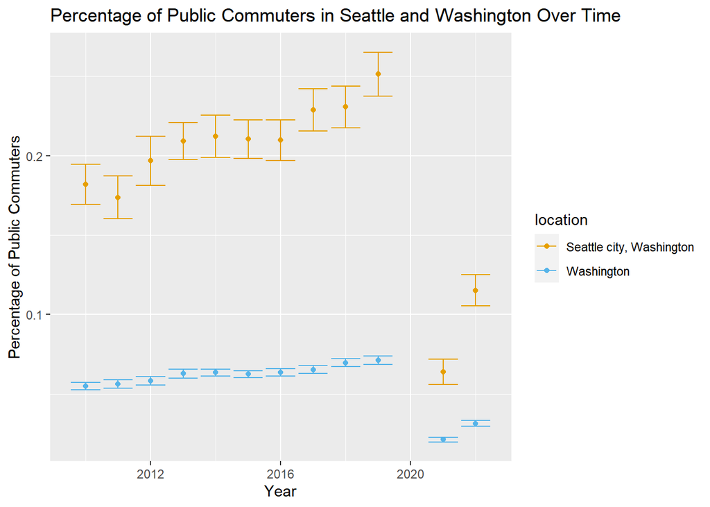

The percent of commuters that used public transportation were much higher in Seattle over the years comparative to Washington state as a whole. There was a huge drop-off in public transportation commuters after the pandemic. Seattle public commuting experienced a sharp decline at the beginning of the pandemic and has slowly begun to trend upwards. The increase from 2021 to 2022 seems to be much larger than the difference between every other year.

### Does income have a relationship with individuals’ means of transportation? (Do wealthier individuals carpool/take public transportation less?)

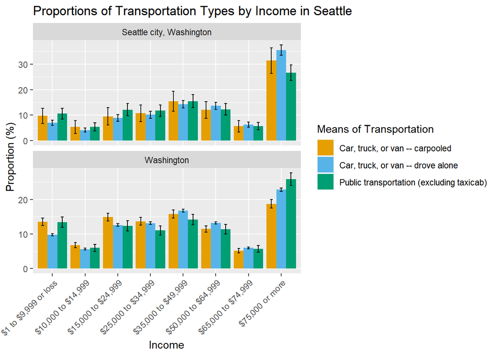

### Do people drive to work less if gas prices are higher?

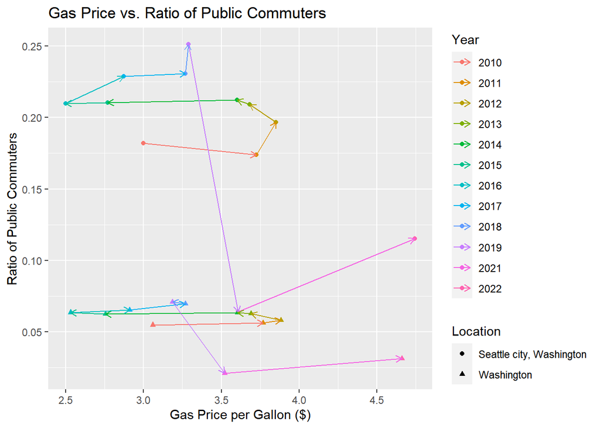

### Do people in a certain age group take public transportation more?

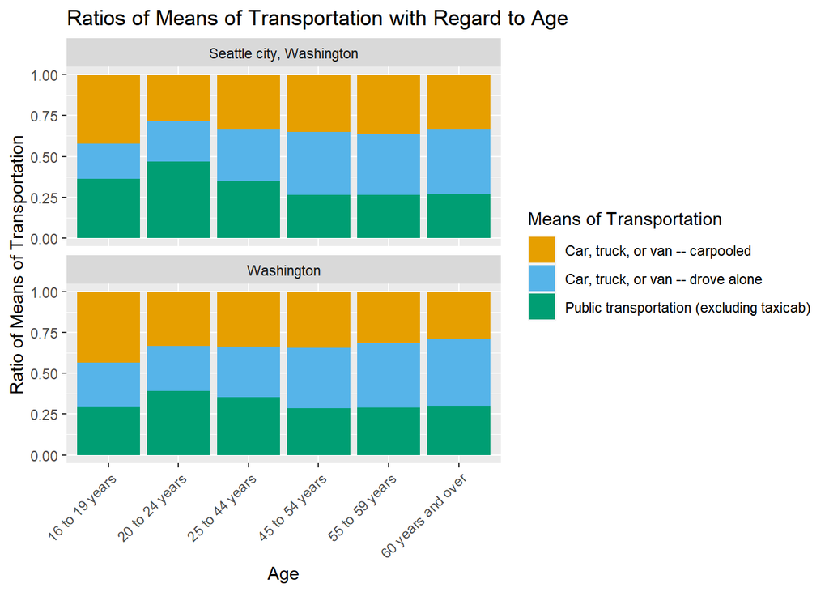

In Seattle, there is a respectable amount of commuters between the age of 20 and 24 who prefer to use public transportation over private vehicles. Commuters between age 16-44 are more likely to use public transportation compared to their counterparts. In Washington state it is slightly different, only commuters between age 20-44 are more likely to use public transportation comparatively.

### Are car crash rates correlated to the proportion of workers that drive alone to work?

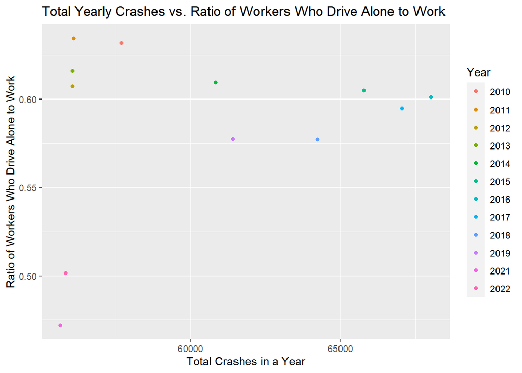

The graph doesn’t show a substantial correlation between individuals driving alone to work and the frequency of crashes in a given year. In both 2021 and 2022, there was a decrease in the number of solo commuters and total crashes. However, these patterns may be caused by reduced traffic by the pandemic. Beyond the pandemic affected years, there appears to be no connection between the total crashes in a year and the number of solo commuters. The data year by year does not show a clear correlation between the two variables.

### Does travel time affect the mode of transportation used?

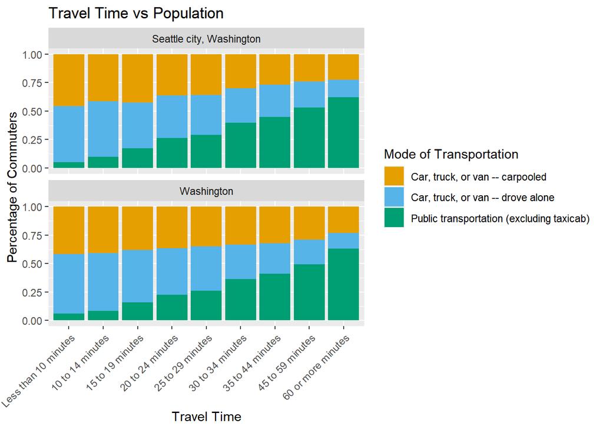

There is a clear correlation between the travel time and the mode of transportation used by the population. There is a noticeable trend that occurs the longer the commute time is. We can see that commuters are more likely to take public transportation the longer it takes for them to commute in Seattle and Washington. Commuters are 50 percent more likely to commute using public transportation when it would take them 60 or more minutes to get to work. It is evident that travel time has a clear connection with the mode of transportation.

# Findings

The percentage of commuters who took public transportation had decreased during the pandemic. This made sense since it was unsafe for individuals to go to work while their health was at risk. Our data was slightly limited by the fact that there was no census data in the beginning of the pandemic. There were no clear correlations when comparing data between gas prices, crashes, and income. The main reason for this was that data for our gas prices and crashes were only given to us yearly. The data was too generalized compared to the census data that made it difficult to find clear correlations between the variables. The range income data was not detailed enough to make an accurate assessment of our research question. The average household income in Seattle is roughly $79,000 and $77,000 in Washington. The data given to us had the highest variable being $75,000 or more, so it made it difficult to truly analyze the amount of wealthier people who took public transportation versus individuals of lower income brackets.

We were able to find clear connections between the amount of people who preferred to use public transportation with longer commute times and the age of commuters who were more likely to take public transportation. Commuters that were in their early adulthood were more inclined to take public transportation compared to their older counterparts. There are many factors that could affect why young adults are more likely to take public transportation. There may be financial conditions that would make it difficult for them to own a vehicle. Public transport is seen as more convenient and younger generations are less likely to be affected by social stigma related to using public transportation. Commuters who prefer to take public transportation when their commute times are longer may be considering the cost of driving, difficulties with parking availability, and traffic congestion. In a city like Seattle, traffic congestion and parking availability are real concerns when deciding whether to drive versus taking public transportation.

In the future we would like to find more detailed auxiliary data in relation to our transportation data to make clearer connections about public commuters. Moving forward, we want to find more detailed data to make more accurate comparisons between different factors related to public commuters. We would prefer to find data such as traffic data, weather data, parking availability and see how that would affect our findings. We could hopefully find a more accurate comparison of income data to see if wealthier people do in fact take transportation less than those in poverty. Looking ahead, our research aims to look into the different factors that influence public commuters’ choices. We envision ourselves incorporating more detailed auxiliary data to find clear patterns that affect the decisions to take public transportation.

# Conclusion

In this project, we worked with various reputable datasets for both the city of Seattle and Washington State. We utilized the package tidycensus to obtain American Community Survey data, combining and joining census data from different years to be able to analyze it longitudinally. We combined the census data with datasets on car crashes and gas prices, which resulted in excluding monthly car crash data.

We, as general members of the public, did not have access to more detailed government databases regarding demographic data. The datasets that we utilized were proven to be too summarized (as they mainly had yearly-based data and thus were largely scaled), so we found few correlations. A key example of such a limitation was that the data’s highest variable for household income in Seattle was $75,000 (while the average income is $79,000), which severely limited the amount of data we worked with, as it excluded the transportation methods of high earners. If we had more detailed data, we would have been able to find more conclusive relationships between our variables.

The main takeaways from this project is that there is a clear dependence on public transit among certain age groups, especially in the city of Seattle (as compared to the rest of Washington state), when commute times are nearly an hour. We also found that younger commuters, specifically within the age range of 16 to 44, were more likely to utilize public transportation as compared to commuters in older age groups. Finally, we discovered that the COVID-19 pandemic limited transit data collected in 2020 and negatively affected public transportation usage as a whole due to social distancing measures.